# Reproducible Data

Assignment with description and code in one document using the provided Activity monitoring data.

## Loading and preprocessing the data

Unzip the Activity file

```r
library(dplyr)
unzip(zipfile = "activity.zip")
```

Load the data

```r
ActivityData <- read.csv(file="activity.csv", header=TRUE)
```

## What is mean total number of steps taken per day?

Create data set which aggregates the total number of steps for each day.

```r
subDat3 <- aggregate(steps ~ date, data = ActivityData, sum)
```

Make a histogram of the total number of steps taken each day

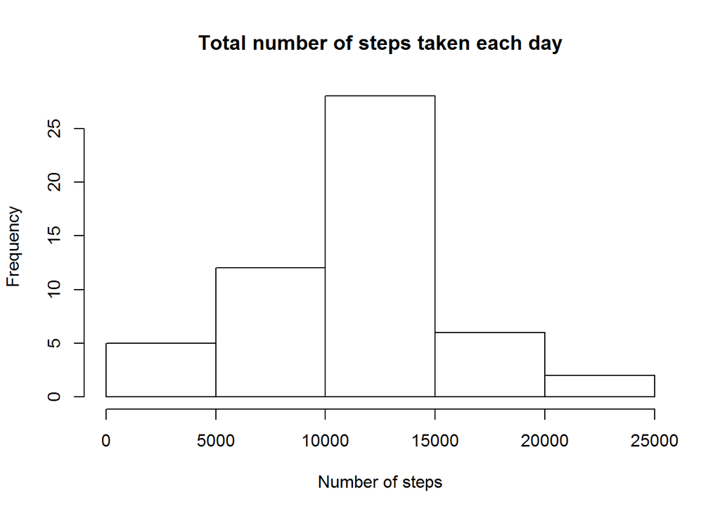

Calculate the mean and median total number of steps taken per day

```r
meanst <- summarize(subDat3, mean(steps))
medianst <- summarize(subDat3,median(steps))
```

## What is the average daily activity pattern?

```r
subDat4 <- aggregate(steps ~ interval, data = ActivityData, mean)
```

Create a time series plot of the 5-minute interval and the average number of steps taken, averaged across all days.

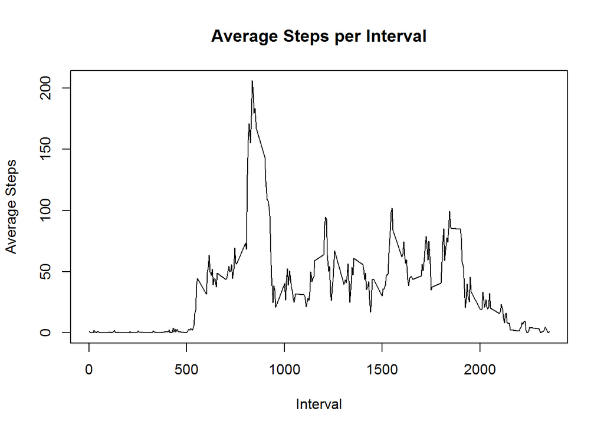

Identify 5-minute interval, on average across all the days in the dataset, that contains the maximum number of steps

```r
subDat4[which(subDat4$steps == max(subDat4$steps, na.rm = TRUE)), ]
```

```
##     interval    steps
## 104      835 206.1698
```

```r
maxrw <- subDat4$interval[104]
```

The 835 interval contains the maximum number of steps.

## Imputing missing values

1. Report the total number of missing values in the dataset

```r
miss <- sum(is.na(ActivityData))
```

The total number of missing values is 2304.

2. Replace missing values with average steps per interval and create a new dataset with the missing data filled in.

```r
NewDataSet <- ActivityData

for (i in 1:nrow(NewDataSet)) {
  if (is.na(NewDataSet$steps[i])) {
    # Find the index value for when the interval matches the average
    itver <- which(NewDataSet$interval[i] == subDat4$interval)
    # Assign the value to replace the NA
    NewDataSet$steps[i] <- subDat4[itver,]$steps
  }
}
```

Create data set that sums the number of steps taken per day in data set with filled in values.

```r
subfillDat3 <- aggregate(steps ~ date, data = NewDataSet, sum)
```

Histogram of the total number of steps taken each day using new data set.

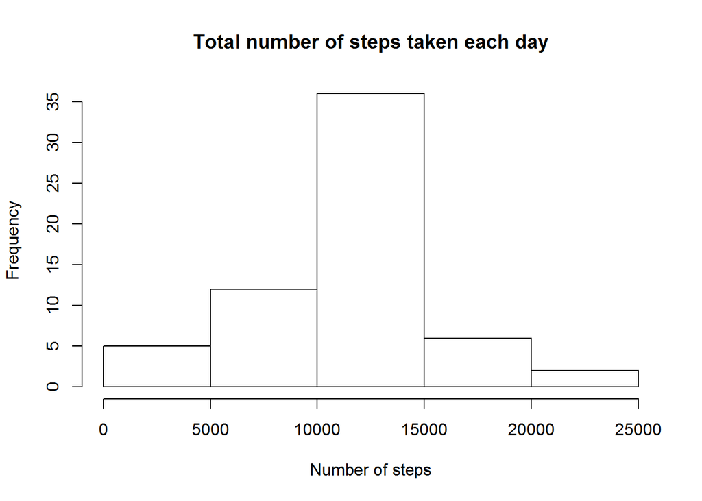

```r
meanfillst <- summarize(subfillDat3, mean(steps))
medianfillst <- summarize(subfillDat3,median(steps))
```

## Are there differences in activity patterns between weekdays and weekends?

1. New factor variable in the dataset with two levels – “weekday” and “weekend” indicating whether a given date is a weekday or weekend day.

```r
NewDataSet$date <- as.Date(NewDataSet$date)
#create a vector of weekdays
wkdays <- c('Monday', 'Tuesday', 'Wednesday', 'Thursday', 'Friday')
#Use `%in%` and `weekdays` to create a logical vector
#convert to `factor` and specify the `levels/labels`
NewDataSet$wDay <- factor((weekdays(NewDataSet$date) %in% wkdays),
                   levels=c(FALSE, TRUE), labels=c('weekend', 'weekday'))

subNewDat4 <- subset(NewDataSet,wDay=="weekday")
subNewDat4wken <- subset(NewDataSet,wDay=="weekend")

AvgsubNewDat4 <-aggregate(steps ~ interval, data = subNewDat4, mean)
AvgsubNewDat4wken <-aggregate(steps ~ interval, data = subNewDat4wken, mean)
```

Plots containing a time series plot of the 5-minute interval and the average number of steps taken, averaged across all weekday days or weekend days.

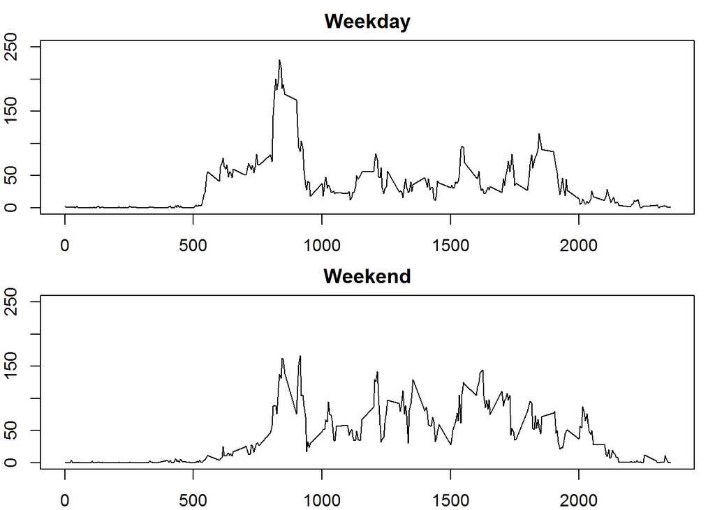

Weekend activity differs from weekday in that the step activity starts in later intervals.